# STAT2000: Applied Statistics and Research Methods

# Lab 5 - Week 6

#### Recall Lecture 5:

- Revision: One-way fixed effects ANOVA, Unplanned comparisons, Contrasts,
- Two-way ANOVA, Interactions
- Common study designs: Extensions on Two-way ANOVA

### Lab Objectives

On completion of this lab you will be able to:

- Fit a two-way ANOVA.
- Fit a factorial ANOVA model with an interaction term.
- Interpret the interaction effect

### Overview

In the Week 5 lecture we reviewed some of the content covered in the course so far: One-way fixed effects ANOVA; Unplanned comparisons; Contrasts. We then extended the one-way ANOVA to a two-way fixed effects ANOVA where we have two main factors and an interaction term. We also looked at factorial ANOVA as well other types of designs.

#### Data Files

Download Lab 05 - Recall.sav  
Download Lab 05 - Advertising.sav

## 5.1 Two Way ANOVA

Recall the example provided in Lecture 5:

- Does one’s mood influence how well things are remembered? A psychologist decides to research this question using two factors.
- Factor A represents the emotional condition under which the subjects are required to learn a list of words. Subjects are made to feel either happy or sad.
- Factor B represents the emotional condition under which the subject’s memory is tested. Subjects are made to feel happy or sad before they are told to recall words
- The response variable is the number of words recalled. The data appears in *Lab 05 - Recall.sav*.

Number of words recalled for given levels of mood during learning and at recall.

#### 1. Express the two-way ANOVA model required for analysing this data algebraically (i.e., in terms of a mathematical equation). Clearly define all the symbols in the context of this example.

##### Solutions

With two fixed factors, the ANOVA model is:

$$Y_{ijk} = \mu_{ij} + \epsilon_{ijk}$$
$$Y_{ijk} = \mu + \alpha_i + \beta_j + \alpha\beta_{ij} + \epsilon_{ijk}$$

where in this example

- $i$ = 1 or 2 identifying a Sad or Happy mood when learning the list of words.
- $j$ = 1 or 2 identifying a Sad or Happy mood when recalling the list of words.
- $k$ = 1,…, 5 distinguishes the 5 different subjects within each treatment group.
- $Y_{ijk}$ is the number of words recalled by the kth subject in the cell corresponding to the ith level of learning mood and the jth level of recall mood.
- $\mu_{ij}$ is the population mean number of words recalled for a (theoretical) population of people who learnt the list in mood i and recalled the list in mood j. Thus it is the population mean corresponding to each treatment and can be broken down into components using $\mu_{ij} = \mu + \alpha_i + \beta_j + \alpha\beta_{ij}$
- $\mu$ is the overall population mean number of words remembered across all learning moods and recall moods.
- $\alpha_i$ is the fixed effect of the ith learning mood on the number of words remembered.
- $\beta_j$ is the fixed effect of the jth recall mood on the number of words remembered.
- $\alpha\beta_{ij}$ is the interaction effect of the ith learning mood and jth recall mood on the number of words remembered.
- $\epsilon_{ijk}$ is the error term of the observation, $Y_{ijk}$, assumed to be distributed normally with a mean of zero and variance of $\sigma^2$. It is the remaining unexplained variation after the effects of learning mood and recall mood and any interaction effect have been accounted for.

#### 2. Fit the appropriate ANOVA model. Record the means and obtain plots of the factor level (group) sample means for each factor to enable a visual consideration of the effects of the factors.

[figure not shown]

It’s possible to use a number of different functions to achieve this, but for the sake of expedience, let’s use the *jmv* package’s `ANOVA()` function.

```r
library(jmv)
data <- haven::read_sav('Lab 05 - Recall.sav')
data <- as.data.frame(data)

ANOVA(
  data = data,
  formula = WordsRecalled ~ LearningMood * RecallMood,
  emMeans = ~LearningMood+RecallMood+LearningMood:RecallMood,
  emmTables = TRUE)
```

The more traditional way in R would be as follows:

```r
data <- haven::read_sav('Lab 05 - Recall.sav')
data <- as.data.frame(data)

lm_1 = lm(WordsRecalled~LearningMood*RecallMood, data = data)
anova(lm_1)

library("emmeans")
# LearningMood marginal means
emmeans(lm_1,specs = ~ LearningMood, data = data)
emmip(lm_1,formula = ~ LearningMood, data = data, CIs = T, PIs = F)

# RecallMood marginal means
emmeans(lm_1,specs = ~ RecallMood, data = data)
emmip(lm_1,formula = ~ RecallMood, data = data, CIs = T, PIs = F)

# Interaction
emmeans(lm_1,specs = ~ LearningMood|RecallMood, data = data)
emmip(lm_1,formula = ~ RecallMood~LearningMood, data = data, CIs = T, PIs = F)
```

[figure not shown]

Analyses -> ANOVA -> ANOVA. This is a two-way ANOVA, so we’ll be specifying two factors this time. We want to produce 3 plots, one plot showing the main-effect of `LearningMood`, one plot showing the main-effect of `RecallMood`, and one plot showing the interaction between `LearningMood` and `RecallMood`. To create these plots, come down to the *Estimated Marginal Means* section. In this section, we can specify the *terms* that we want to plot. To begin with, add `LearningMood` into *Term 1*. This should produce a main-effect plot of `LearningMood`. To create a second plot, click “+ New Term”. This will provide you with a slot to add `RecallMood` into; providing a plot of its main-effect. Finally, click “+ New Term” again, and this time add *both* `LearningMood` and `RecallMood` into that term box. This will produce an *interaction plot* of `LearningMood` and `RecallMood`.

##### Solutions

```r
library(jmv)
data <- haven::read_sav('Lab 05 - Recall.sav')
data <- as.data.frame(data)

ANOVA(
  data = data,
  formula = WordsRecalled ~ LearningMood * RecallMood,
  emMeans = ~LearningMood+RecallMood+LearningMood:RecallMood,
  emmTables = TRUE)
```

```
##
##  ANOVA
##
##  ANOVA
##  --------------------------------------------------------------------------------------
##                               Sum of Squares    df    Mean Square    F         p
##  --------------------------------------------------------------------------------------
##    LearningMood                       361.25     1         361.25     47.07    < .001
##    RecallMood                           8.45     1           8.45      1.10     0.310
##    LearningMood:RecallMood           7566.05     1        7566.05    985.80    < .001
##    Residuals                          122.80    16           7.68
##  --------------------------------------------------------------------------------------
##
##
##  ESTIMATED MARGINAL MEANS
##
##  LEARNINGMOOD
##
##  Estimated Marginal Means - LearningMood
##  ---------------------------------------------------
##    LearningMood    Mean    SE       Lower    Upper
##  ---------------------------------------------------
##    happy           65.9    0.876     64.0     67.8
##    sad             57.4    0.876     55.5     59.3
##  ---------------------------------------------------
##
##
##  RECALLMOOD
##
##  Estimated Marginal Means - RecallMood
##  -------------------------------------------------
##    RecallMood    Mean    SE       Lower    Upper
##  -------------------------------------------------
##    happy         62.3    0.876     60.4     64.2
##    sad           61.0    0.876     59.1     62.9
##  -------------------------------------------------
##
##
##  LEARNINGMOOD:RECALLMOOD
##
##  Estimated Marginal Means - LearningMood:RecallMood
##  ----------------------------------------------------------------
##    RecallMood    LearningMood    Mean    SE      Lower    Upper
##  ----------------------------------------------------------------
##    happy         happy           86.0    1.24     83.4     88.6
##                  sad             38.6    1.24     36.0     41.2
##    sad           happy           45.8    1.24     43.2     48.4
##                  sad             76.2    1.24     73.6     78.8
##  ----------------------------------------------------------------
```

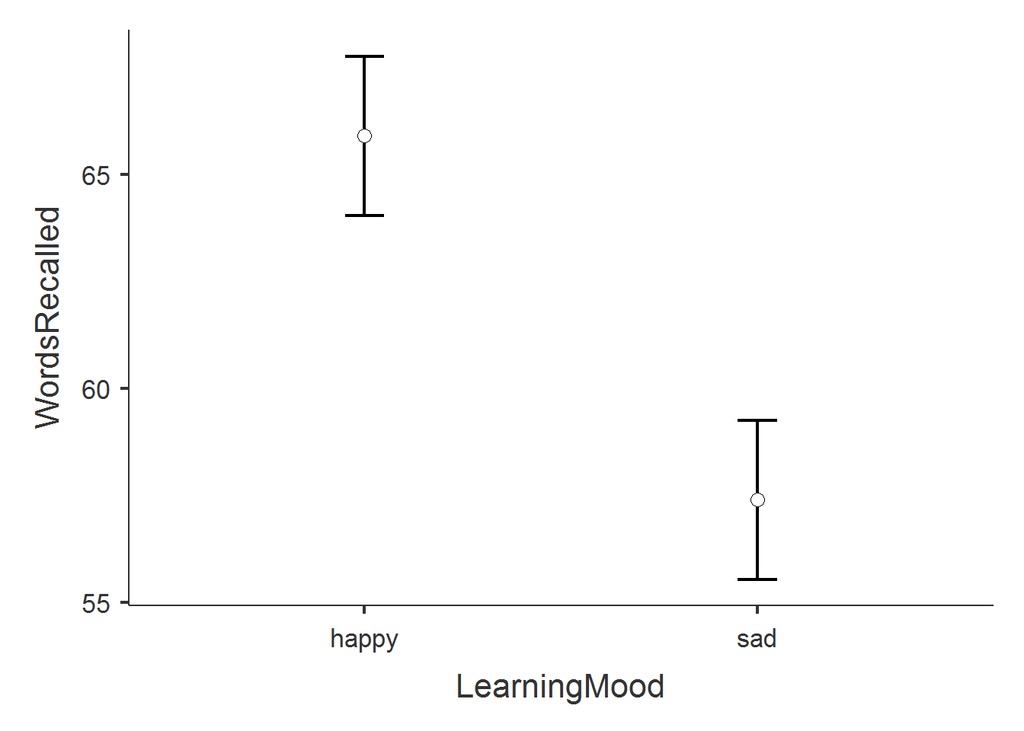

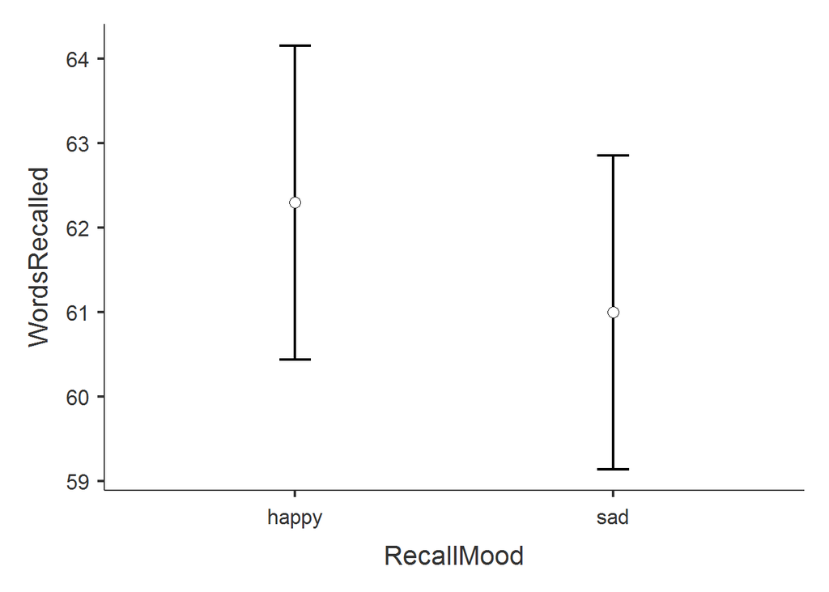

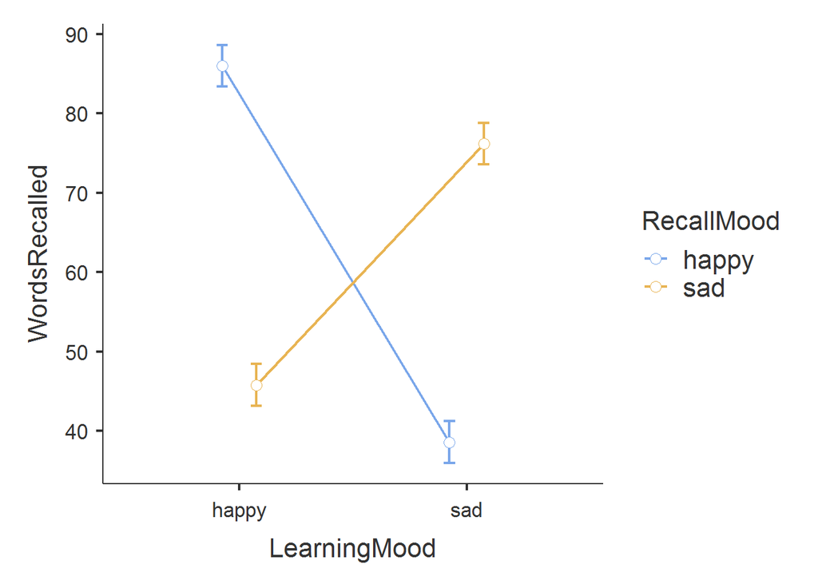

#### 3. Write the relevant null and alternative hypotheses for testing whether there is an interaction between the mood during learning and the mood during recall in how these factors relate to the number of words recalled. What is the relevant test statistic, p-value and your decision?

##### Solutions

$H_0: \alpha\beta_{ij} = 0$ for all i, j

$H_a: \alpha\beta_{ij} ≠ 0$ for at least one i, j pair

The relevant test statistic is F = 985.80, associated p-value < 0.001 and thus $H_0$ is rejected.

#### 4. Write the relevant null and alternative hypotheses for testing whether the mood during learning has an effect on the number of words recalled. What is the relevant test statistic, p-value and your decision?

##### Solutions

$H_0: \alpha_i = 0$ for all i

$H_a: \alpha_i ≠ 0$ for at least one i

The relevant test statistic is F = 47.07, associated p-value < 0.001 and thus $H_0$ is rejected.

#### 5. Write the relevant null and alternative hypotheses for testing whether the mood during recall has an effect on the number of words recalled. What is the relevant test statistic, p-value and your decision?

##### Solutions

$H_0: \beta_j = 0$ for all j

$H_a: \beta_j ≠ 0$ for at least one j

The relevant test statistic is F = 1.10, associated p-value = 0.310 and thus $H_0$ is not rejected.

#### 6. Provide a concluding paragraph that would be appropriate to include in a report summarising the results of this research.

##### Solutions

There is a statistically significant interaction effect on the population mean number of words recalled due to both the mood when learning and mood when recalling (p < .001); this is also evident from the graph which shows the difference in means for a given level of mood at recall is affected by the level of mood when learning. Mood at recall does not itself have a statistically significant effect on the population mean number of words recalled (p=0.31) whilst mood when learning does (p < .001).

The key finding is that the effect of recall moods on the response variable is completely different depending on the level of the mood when learning the words (the interaction effect).

We are 95% confident that the population mean number of words recalled when:

- Happy at both learning and recall lies between 83.4 and 88.6
- Sad at both learning and recall lies between 73.6 and 78.8
- Happy at learning and sad at recall lies between 43.2 and 48.4
- Sad at learning and happy at recall lies between 36.0 and 41.2

#### 7. Use this example to explain why is it important to always check for an interaction effect before interpreting the main effects.

##### Solutions

Someone who just looked at the output superficially may look at the results of the test of the effect of recall mood and declare that it has no statistically significant effect based on the p-value of 0.31. If you look at the means plot for the recall mood factor it certainly shows that averaged over the levels of the learning mood factor there is no effect of recall mood on the number of words recalled. However, in this case, it is certainly not correct to say that recall mood does not have an effect. Recall mood has a very large effect but the effect depends on the level of the learning mood factor’s level.

This is why you should always check for an interaction effect first before trying to test for the significance of individual factors or interpret what is really happening.

## 5.2 Factorial (multi-way) ANOVA

A researcher is interested in how well consumers recall television advertising that they have seen. Two factors that the researcher considers may have an effect are the existence of a celebrity in the advertisement as well as the gender of the primary spokesperson in the advertisement. Individuals for the study are randomly selected and then randomly allocated to groups. Each of the groups will watch a set piece of television programming for two hours with several advertisements that meet the respective groups criteria randomly scattered though ordinary advertisements.

After the viewing the subjects are tested on their recall of details shown in the advertisements and provided a score of their recall. A higher score indicates better recall of advertising details. The researcher wishes to test at the 5% significance level.

The results of the study are in *Lab 05 - Advertising.sav*. If using R, remember to convert the predictor variables to factors using `as.factor()`.

```r
data <- haven::read_sav('Lab 05 - Advertising.sav')
data <- as.data.frame(data)
data$Celebrity <- as.factor(data$Celebrity)
data$GenderSpokes <- as.factor(data$GenderSpokes)
data$GenderViewer <- as.factor(data$GenderViewer)
```

#### 1. The researcher has asked that you perform a statistical analysis to determine if the grade of celebrity and or gender of the spokesperson effects recall in television advertisements. As part of your analysis, be sure to:

- Include the null and alternative hypotheses for the elements of the model you are testing.
- Justify your final decision.

This requires a two way ANOVA to be performed.

##### Solutions

```r
model <- lm(Score ~ Celebrity * GenderSpokes, data)
anova(model)
```

```
## Analysis of Variance Table
##
## Response: Score
##                        Df  Sum Sq Mean Sq F value  Pr(>F)
## Celebrity               2  7541.8  3770.9  3.1521 0.06089 .
## GenderSpokes            1  2167.2  2167.2  1.8115 0.19090
## Celebrity:GenderSpokes  2  2124.5  1062.3  0.8879 0.42460
## Residuals              24 28712.0  1196.3
## ---
## Signif. codes:  0 '***' 0.001 '**' 0.01 '*' 0.05 '.' 0.1 ' ' 1
```

First we are required to test the interaction effect between the two factors. Let factor A be `Celebrity` and factor B be `GenderSpokes`.

$H_0: \alpha\beta_{ij} = 0$

$H_a:$ at least one effect is non-zero,

where $\alpha\beta_{ij}$ represents the interaction effect between the ith and jth level of the factor A and B.

Given the p-value of 0.425 is greater then our significance level, we are unable to identify a statistically significant interaction effect.

We should also test both main effects.

$H_0: \alpha_i = 0$

$H_a:$ at least one $\alpha_i$ is non-zero

Here $\alpha_i$ represents the effect due to the ith level of the `Celebrity` factor.

Given the p-value of 0.061 is greater then our significance level, we are unable to identify a statistically significant effect for the `Celebrity` main effect.

$H_0: \beta_j = 0$

$H_a:$ at least one $\beta_j$ is non-zero

The $\beta_j$ represents the effect due to the jth level of the `GenderSpokes` factor.

Given the p-value of 0.191 is greater then our significance level, we are unable to identify a statistically significant effect for the `GenderSpokes` main effect.

#### 2. After providing your analysis to the researcher, she informs you that you forgot a factor in the model. An additional factor for which data was collected was intended to be included in the analysis. The additional factor is the gender of the person viewing the advertisements. Run your analysis again including the additional factor.

1. Looking at the ANOVA table, are there any factors of the model that are now significant? Be sure to indicate your null and alternative hypothesis for these factors as well as check the assumptions for the analysis.
2. Explain the relationship with any of the interaction terms that are identified as being statistically significant. Use a marginal means plot (profile plots) to help with this.

##### Solutions

Below is the ANOVA table for the three way ANOVA.

```r
model <- lm(Score ~ Celebrity * GenderSpokes * GenderViewer, data)
anova(model)
```

```
## Analysis of Variance Table
##
## Response: Score
##                                     Df  Sum Sq Mean Sq F value  Pr(>F)
## Celebrity                            2  7541.8  3770.9  4.4349 0.02717 *
## GenderSpokes                         1  2167.2  2167.2  2.5488 0.12778
## GenderViewer                         1    90.8    90.8  0.1068 0.74755
## Celebrity:GenderSpokes               2  2093.6  1046.8  1.2311 0.31541
## Celebrity:GenderViewer               2  4001.7  2000.8  2.3531 0.12363
## GenderSpokes:GenderViewer            1  6777.0  6777.0  7.9703 0.01126 *
## Celebrity:GenderSpokes:GenderViewer  2  2568.3  1284.2  1.5103 0.24755
## Residuals                           18 15305.1   850.3
## ---
## Signif. codes:  0 '***' 0.001 '**' 0.01 '*' 0.05 '.' 0.1 ' ' 1
```

Let factor A, B, and C be `Celebrity`, `GenderSpokes`, and `GenderViewer` respectively. $\alpha_i$ represents the effect due to the ith level of the `Celebrity` factor, $\beta_j$ represents the effect due to the jth level of the `GenderSpokes` factor, $\gamma_k$ represents the effect due to the kth level of the `GenderViewer` factor. $\alpha\beta_{ij}$ represents the interaction effect between the ith and jth level of the factor A and B. $\alpha\gamma_{ik}$ represents the interaction effect between the ith and kth level of the factor A and C. $\beta\gamma_{jk}$ represents the interaction effect between the jth and kth level of the factor B and C. $\alpha\beta\gamma_{ijk}$ represents the three way interaction effect between the factor A, B, and C.

Of the interaction terms:

$H_0: \beta\gamma_{jk} = 0$

$H_a: \beta\gamma_{jk} \ne 0$

Since the p-value (0.0113) is less than 0.05, there is a statistically significant interaction between the gender of the viewer and the gender of the spokesperson.

For the main effects:

$H_0: \alpha_i = 0$

$H_a: \alpha_i \ne 0$

Since the p-value (0.027) is less than 0.05, there is a statistically significant effect due to the level of celebrity of the spokesperson.

**Assumptions**

Randomness: Told that the subjects are randomly selected and randomly allocated to groups.

Independence: Due to random sampling, can assume this.

Equal variance:

```r
leveneTest(model, center='mean')
```

```
## Levene's Test for Homogeneity of Variance (center = "mean")
##       Df F value  Pr(>F)
## group 11  2.2781 0.05844 .
##       18
## ---
## Signif. codes:  0 '***' 0.001 '**' 0.01 '*' 0.05 '.' 0.1 ' ' 1
```

The p-value (p = 0.058) is greater than 0.05 indicating that there is not enough evidence to violate this assumption. Although it is borderline, a transformation or non-parametric test may be appropriate.

Normality:

```r
res <- residuals(model)
shapiro.test(res)
```

```
##
##  Shapiro-Wilk normality test
##
## data:  res
## W = 0.9557, p-value = 0.2396
```

The residuals have been combined and tested all together. The test of normality does not provide evidence to reject this assumption (p=0.240).

Outliers:

The side by side box plot does not indicate any outliers.

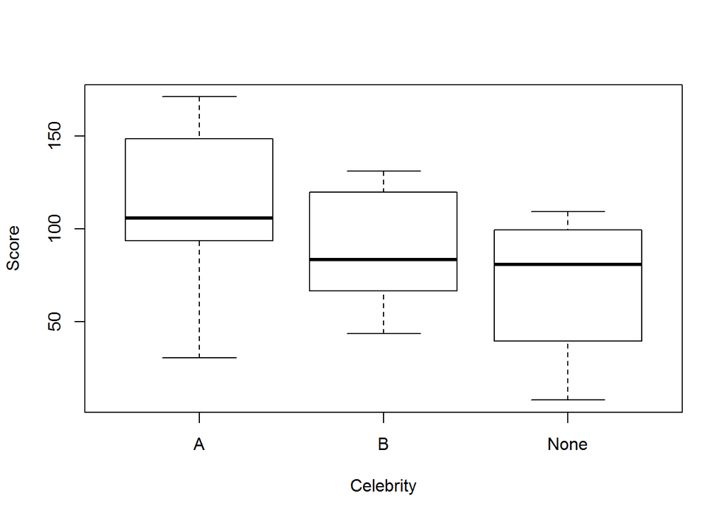

```r
plot(Score ~ Celebrity, data)
```

2. Below is the marginal means plot for gender of the spokesperson and gender of the viewer.

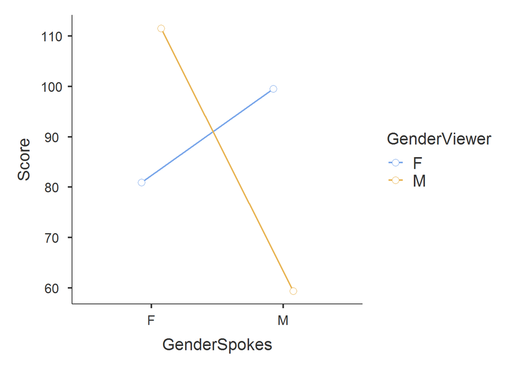

```r
jmv::ANOVA(
  formula = Score ~ GenderSpokes * GenderViewer,
  data = data,
  emMeans = ~GenderSpokes:GenderViewer,
  emmPlotError = 'none'
)$emm
```

It appears that if you are a male viewer, you score higher on recalling details of the advertisement when the spokesperson is female. Where as if you are a female viewer you are more likely to score higher recalling when the spokesperson is male. This is shown by the lines crossing each other in the above plot.

You could also create the plot using the `emmeans` package as follows.

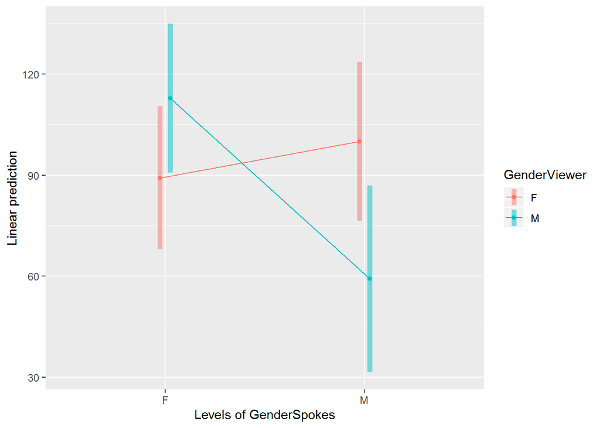

```r
emmip(model,formula = ~ GenderViewer~GenderSpokes, data = data, CIs = T, PIs = F)
```

#### 3. You are now told that when individuals were allocated to groups, they were informed of the style of advertisements they were going to be eventually tested on. Does this information change the validity of any conclusions you are able to make from the experiment?

As people were informed of what to look out for, this may make the results of the experiment not generalisable to the general public. For example, knowing that you’re supposed to be looking at adds with celebrities, you may recognise adds with celebrities and pay closer attention. This could be the reason that this main effect was significant.

## 5.3 Learning Recall Revisted

#### 1. In Exercise 5.1, there was no question on testing the assumptions of the two-way ANOVA. Using the *Lab 05 - Recall.sav* data set, test the assumptions when a two-way ANOVA is fitted.

##### Solutions

We are not explicitly told about whether the individuals are randomly selected and or randomly allocated to treatment groups. Therefore randomness and independence may be violated. We should also test for equality of variance, normality and outliers.

```r
data <- haven::read_sav('Lab 05 - Recall.sav')
data <- as.data.frame(data)

lm_1 = lm(WordsRecalled~LearningMood*RecallMood, data = data)
anova(lm_1)
```

```
## Analysis of Variance Table
##
## Response: WordsRecalled
##                         Df Sum Sq Mean Sq F value    Pr(>F)
## LearningMood             1  361.3   361.3  47.068 3.830e-06 ***
## RecallMood               1    8.4     8.4   1.101    0.3096
## LearningMood:RecallMood  1 7566.0  7566.0 985.805 8.373e-16 ***
## Residuals               16  122.8     7.7
## ---
## Signif. codes:  0 '***' 0.001 '**' 0.01 '*' 0.05 '.' 0.1 ' ' 1
```

```r
leveneTest(lm_1)
```

```
## Levene's Test for Homogeneity of Variance (center = median)
##       Df F value Pr(>F)
## group  3  0.3272 0.8057
##       16
```

```r
shapiro.test(residuals(lm_1))
```

```
##
##  Shapiro-Wilk normality test
##
## data:  residuals(lm_1)
## W = 0.90363, p-value = 0.04825
```

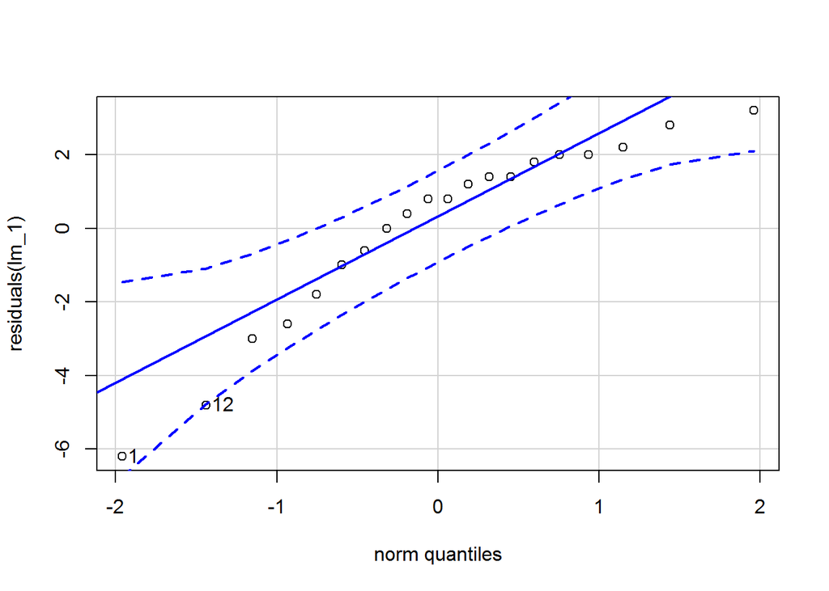

```
## [1]  1 12
```

```r
qqPlot(residuals(lm_1))
```

Levene’s test shows no evidence (p = 0.81) of non-equal variance between the groups therefore this assumption is satisfied. A review of the Shapiro Wilk test of normality indicates that the assumption of normaility is violated (p = 0.048). We should therefore look at doing a transformation of the response variable.

#### 2. One of the assumptions should have failed. Transform the response variable and re-run the model using the new response variable.

##### Solutions

```r
data$WordsRecalled_Log = log(data$WordsRecalled)
lm_1_Log = lm(WordsRecalled_Log~LearningMood*RecallMood, data = data)
anova(lm_1_Log)
```

```
## Analysis of Variance Table
##
## Response: WordsRecalled_Log
##                         Df  Sum Sq Mean Sq  F value    Pr(>F)
## LearningMood             1 0.10611 0.10611  41.6698 7.946e-06 ***
## RecallMood               1 0.00289 0.00289   1.1334    0.3028
## LearningMood:RecallMood  1 2.15130 2.15130 844.8488 2.820e-15 ***
## Residuals               16 0.04074 0.00255
## ---
## Signif. codes:  0 '***' 0.001 '**' 0.01 '*' 0.05 '.' 0.1 ' ' 1
```

```r
leveneTest(lm_1_Log)
```

```
## Levene's Test for Homogeneity of Variance (center = median)
##       Df F value Pr(>F)
## group  3  0.8006 0.5115
##       16
```

```r
shapiro.test(residuals(lm_1_Log))
```

```
##
##  Shapiro-Wilk normality test
##
## data:  residuals(lm_1_Log)
## W = 0.91742, p-value = 0.08838
```

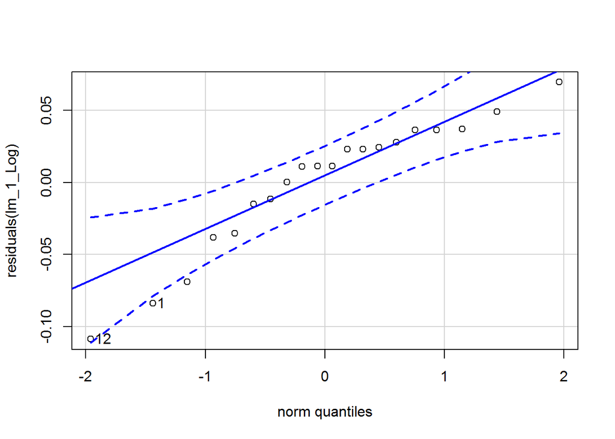

```
## [1] 12  1
```

```r
qqPlot(residuals(lm_1_Log))
```

Looking at the assumptions first, the normaility and equal variance assumption are both now satisfied.

```r
anova(lm_1_Log)
```

```
## Analysis of Variance Table
##
## Response: WordsRecalled_Log
##                         Df  Sum Sq Mean Sq  F value    Pr(>F)
## LearningMood             1 0.10611 0.10611  41.6698 7.946e-06 ***
## RecallMood               1 0.00289 0.00289   1.1334    0.3028
## LearningMood:RecallMood  1 2.15130 2.15130 844.8488 2.820e-15 ***
## Residuals               16 0.04074 0.00255
## ---
## Signif. codes:  0 '***' 0.001 '**' 0.01 '*' 0.05 '.' 0.1 ' ' 1
```

Looking at the ANOVA table now, the same factors are statistically significant in explaining the variation in the log of the number of words recalled.

## 5.4 Group Project

## This was a reminder to talk to your tutor about your group project. However the group project has been removed due to COVID-19.

If you have time still, have a go at exercise 5.4.

## 5.5 Homework - Case Study

Read the following research paper. It is available on Blackboard.

Langer, E. J., & Abelson, R. P. (1974). A patient by any other name …: Clinician group difference in labeling bias. *Journal of Consulting and Clinical Psychology*, 42(1), 4–9. https://doi.org/10.1037/h0036054

#### 1. Explain what the response and explanatory variables are in this study. How have they been measured or determined?

##### Solutions

There are two explanatory variables:

**type of clinician** with values *analytic* or *behavioural*. The researchers deliberately recruited their experimental subjects from clinicians with affiliations to university departments known to be oriented towards one type or the other. But they also checked the classification using a questionnaire - see the Subjects and Clinician Groupings paragraphs under the METHOD section of the paper.

**label** with values *patient* or *job applicant*. Half of the analytic clinicians and half of the behavioural clinicians were told that the person they observed in a videotaped interview was a “patient”. The other halves of each group viewed the same tape but were told that the person was a “job applicant”. See Procedure under METHOD for the exact scripts used to instruct each clinician subject.

The response variable was a score between 1, representing very disturbed, and 10, representing very well-adjusted for the clinician’s beliefs about the interviewee. However, this was not assessed directly by the clinician but was an average of ratings by 5 independent raters of the written responses by the clinicians to a set of open-ended questions about the interviewee. See Dependent Measure under METHOD for the details.

#### 2. How has the data been analysed? Is this method appropriate?

##### Solutions

The basic method is a 2 x 2 factorial ANOVA, i.e., a two-way ANOVA where each factor has 2 levels. (To complicate the analysis slightly, a subgrouping of the analytic group of clinicians was also analysed.)

#### 3. Explain why the concept of interaction is so important in this study.

##### Solutions

The main result of this study (see next point) is all about interaction. The effect of the label is virtually non-existent for one group of clinicians, but substantial for the other group.

#### 4. Summarise the main results of the study.

##### Solutions

Regardless of whether the interviewee was labelled as a “patient” or a “job applicant”, the behavioural therapists tended to describe the interviewee as fairly well-adjusted (e.g., 6.26 v 5.98). The average adjustment rating from the analytic therapists however was significantly lower (more disturbed) for those who were told that the interviewee was a “patient” compared to the average rating from those told that he was a “job applicant” (e.g., NYU 5.88 v 2.40).

#### 5. This study is a specific example of how people’s judgement can be influenced or biased by their expectations. Why is this general concept often important when developing the detailed methodology for a research study?

##### Solutions

This study is a specific example of how people’s judgement can be influenced or biased by their expectations. So if you are using people as the subjects of your experiment then you need to make sure that the responses you measure really are caused by the changes being made in the explanatory variables and not confounded by the subjects responding to information consciously or unconsciously provided by the researcher.